# Analysis Report

Although dogs are rated above 10 in general, there is some 367 exceptions rated between 5 and 9 which represents 18% of our dataset mostly because the picture is very odd or the main focus in the picture is not about dogs, even the classification algorithm did a good job predicting dogs where they are clear enought in the pictures and badly where the dogs are not well captured.

- The average rating for all dogs is 11.93/10, 40.20 % of dogs in our dataset are above this number and the best rated one got 1776/10, his picture also is the most favorited and the most retweeted one.
- The most repeated dog names are: tucker, cooper, charlie, lucy with 9 occurances each, the most repeated dog stage in our dataset is floofer which is excpected as most tweets does not contain the exact stage name.

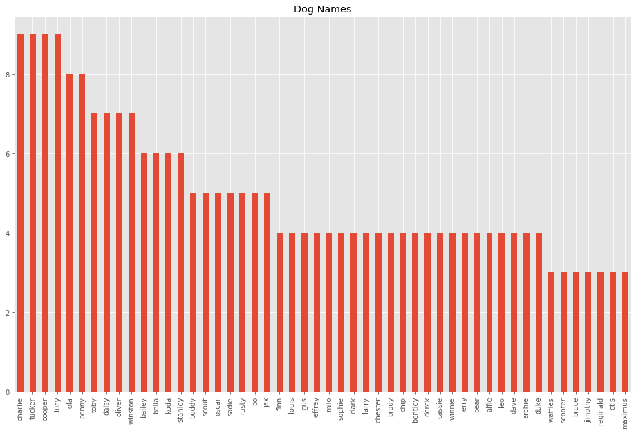

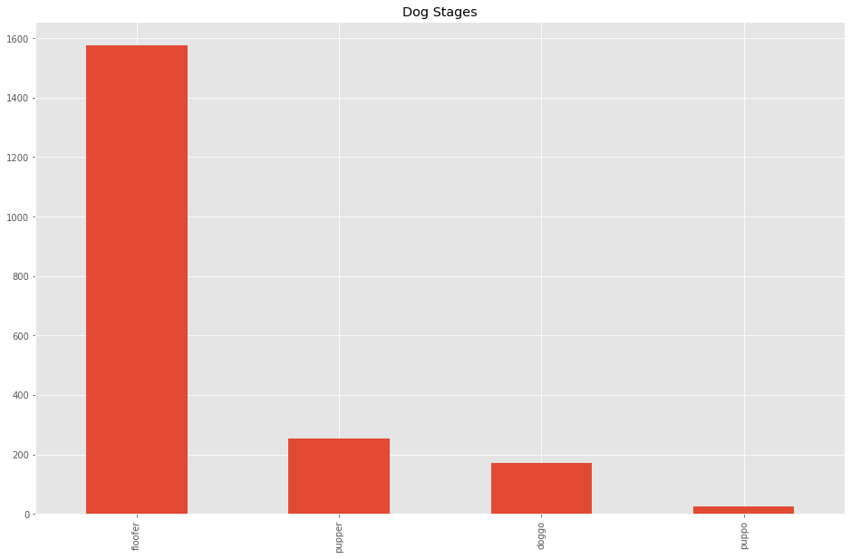

- Tweet favorite count and retweets are corelated.

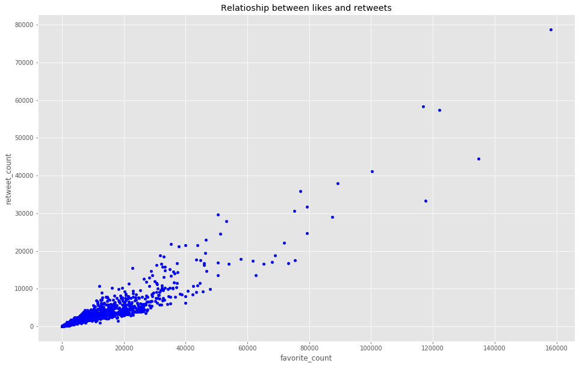

- The least liked and retweeted tweets occurs generally around 4:00 Am.

| Hour | retweet_count | favorite_count |
| --- | --- | --- |
| 0 | 3512.166008 | 13043.996047 |
| 1 | 2357.824373 | 7942.494624 |
| 2 | 1757.298165 | 4878.348624 |
| 3 | 1470.252941 | 4586.782353 |
| 4 | 1134.888889 | 3310.100000 |
| 5 | 1675.240000 | 4205.280000 |
| 6 | 17421.500000 | 36810.750000 |
| 13 | 3473.000000 | 14642.000000 |
| 14 | 1367.333333 | 4515.888889 |
| 15 | 3016.010989 | 10041.747253 |
| 16 | 3452.246154 | 13307.271795 |
| 17 | 2324.878788 | 8447.327273 |
| 18 | 3860.149533 | 10315.859813 |
| 19 | 2672.470588 | 7974.894118 |
| 20 | 2659.475610 | 7975.670732 |
| 21 | 2471.591549 | 7145.366197 |
| 22 | 2470.767123 | 7909.945205 |
| 23 | 2845.531532 | 9682.036036 |

- The tweets of dogs rated bellow the mean are the least liked and/or retweeted with only 13,09 % above the average likes and 13.26 % above the average retweets.
- Opposed to Puppo, The pupper category has the least above average ratings, likes and retweets.

------------------------------floofer Category------------------------------

- There is 1577 tweets about The floofer Category with:
- an average Rating of 12.18706404565631.
- an average Likes of 8304.100824350031.
- an average Retweets of 2466.0963855421687.
- 39.38% of this Dog Category are rated above the overall mean
- 30.31% of tweets for this Dog Category are liked above the overall mean.
- 27.52% of tweets for this Dog Category are retweeted above the overall mean.

------------------------------pupper Category------------------------------

- There is 254 tweets about The pupper Category with:
- an average Rating of 10.838582677165354.
- an average Likes of 6734.9842519685035.
- an average Retweets of 2177.716535433071.
- 36.22% of this Dog Category are rated above the overall mean
- 18.9% of tweets for this Dog Category are liked above the overall mean.
- 21.65% of tweets for this Dog Category are retweeted above the overall mean.

------------------------------doggo Category------------------------------

- There is 172 tweets about The doggo Category with:
- an average Rating of 11.116279069767442.
- an average Likes of 12188.081395348838.
- an average Retweets of 3916.1686046511627.
- 47.67% of this Dog Category are rated above the overall mean
- 46.51% of tweets for this Dog Category are liked above the overall mean.
- 40.7% of tweets for this Dog Category are retweeted above the overall mean.

------------------------------puppo Category------------------------------

- There is 27 tweets about The puppo Category with:
- an average Rating of 12.074074074074074.
- an average Likes of 21280.555555555555.
- an average Retweets of 5847.222222222223.
- 77.78% of this Dog Category are rated above the overall mean
- 66.67% of tweets for this Dog Category are liked above the overall mean.
- 59.26% of tweets for this Dog Category are retweeted above the overall mean.
- The number of dogs per breed doesn't seem to have a great impact on our metrics, for example the golden and labrador retrievers are first and second respectively br the number of dogs belonging to each breed however they are not the highest rated, liked or retweeted, some other breeds like sussex spaniel, japanese spaniel, silky terrier, toy terrier and entlebucher are all bellow the average.
- The average rating for each dog breed is bellow 15, with one exception the dumber category which is the highest average rated breed With above 25/10, 100 % of dogs in this category are rated above the overall average rating, five other breeds are also, namely : tibetan mastiff, briard, afghan hound, silky terrier and standard shnauzer.
- The hishest likes between breeds goes for the saluki breed followed by the afghan hound and then french bulldog, comparing to the overall likes only the afghan hound dogs are 100% liked above the overall mean.
- The tweets about afghan hound dogs are the highest retweeted one and are all above the overall average retweets.

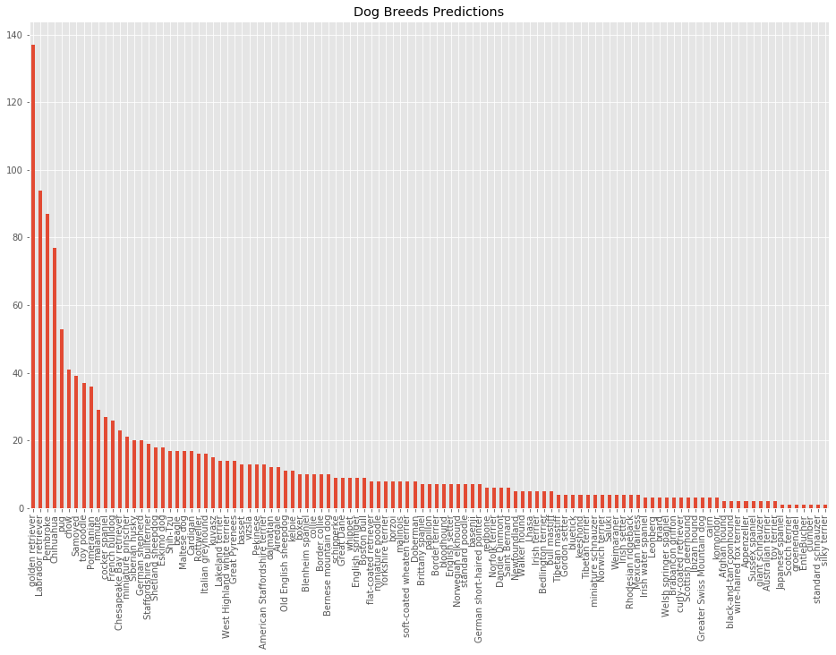

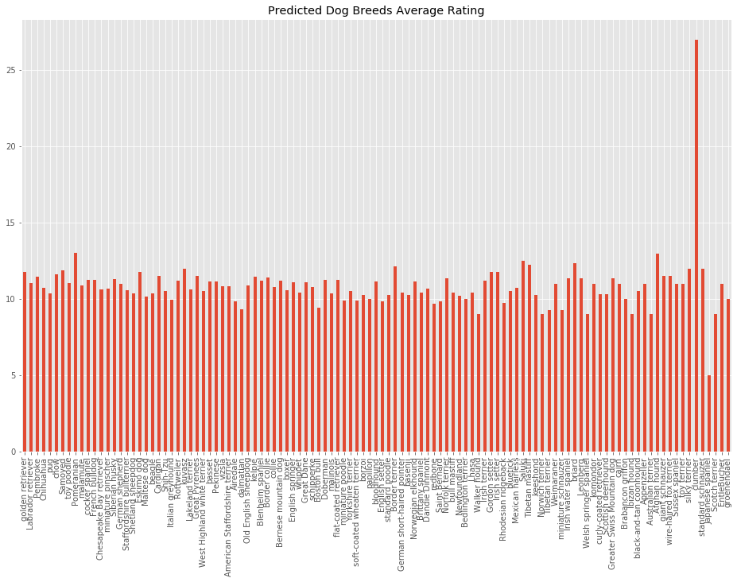

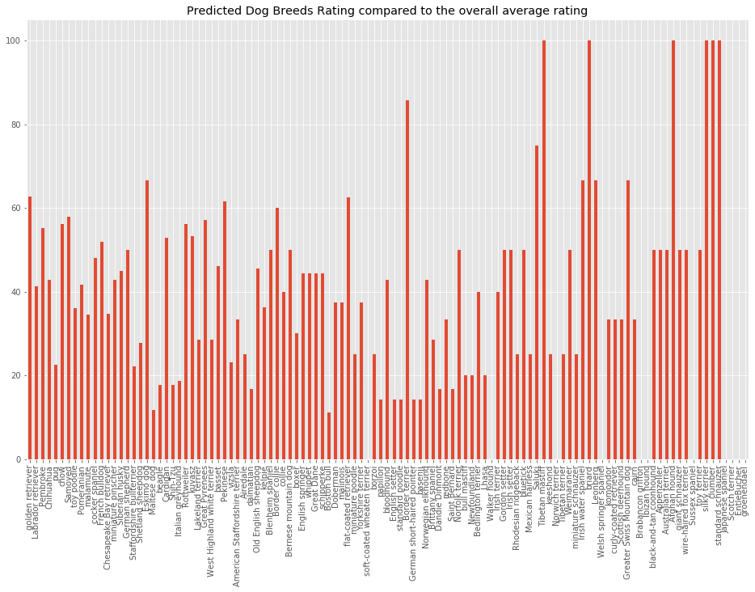

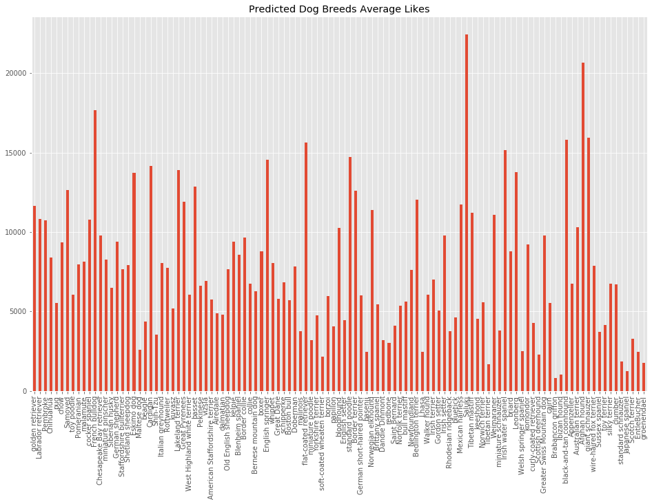

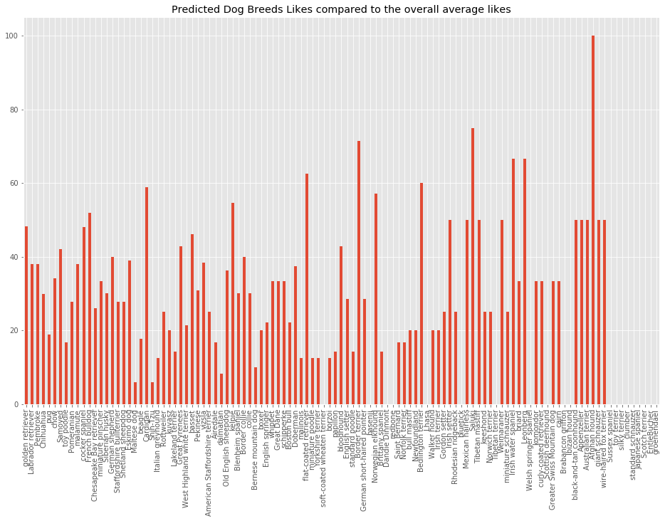

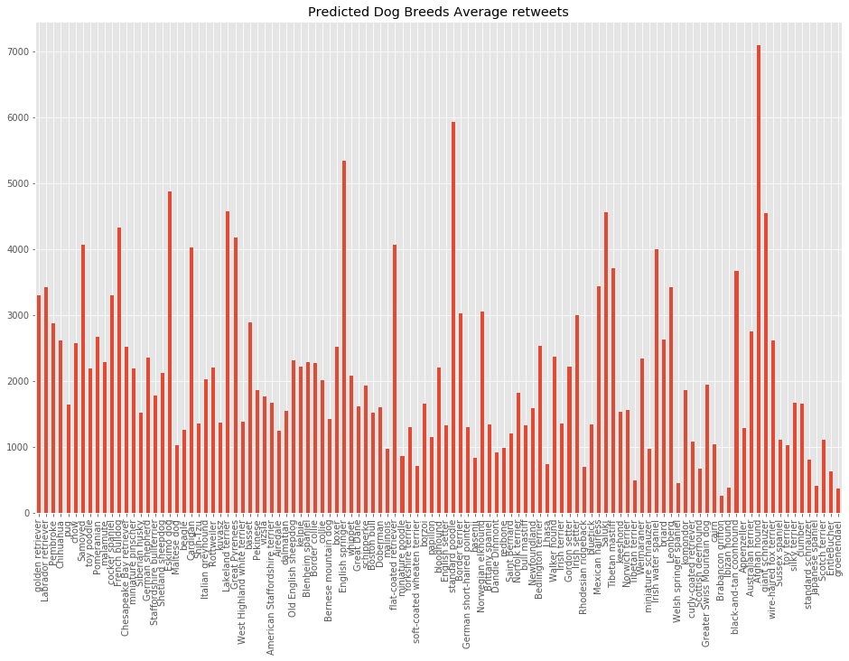

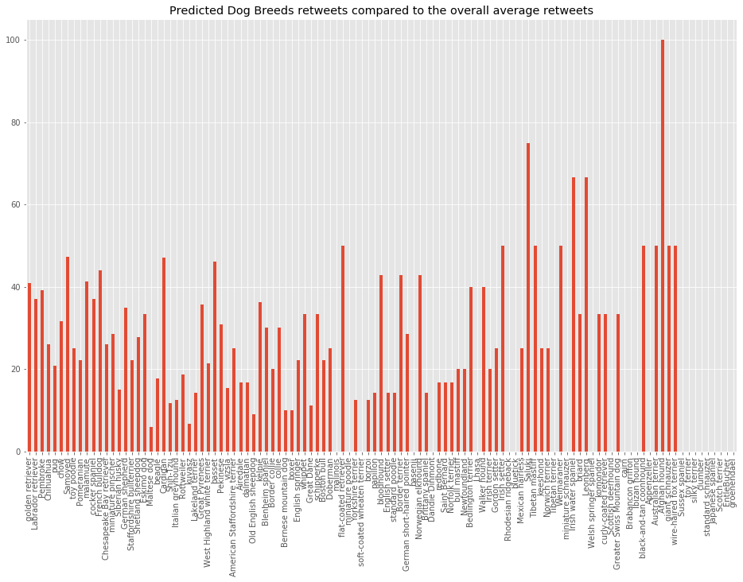